# Beyond the Bubble: Understanding American TV News Viewership Patterns

## Q3: Policy Preferences

```r
# Create a summary of policy preferences by network viewership
network_policy_summary <- cc_media_policy |>
  select(matches("300b_[1-8]"), enviro_carbon, immig_border, guns_assaultban) |>
  # Reshape to long format for network viewing
  pivot_longer(
    cols = matches("300b_"),
    names_to = "network",
    values_to = "watches"
  ) |>
  filter(watches == 1) |>  # Keep only viewers
  mutate(
    network = clean_network_names(network)
  ) |>
  group_by(network) |>
  summarise(
    carbon_support = mean(enviro_carbon == 1, na.rm = TRUE),
    border_support = mean(immig_border == 1, na.rm = TRUE),
    assault_ban_support = mean(guns_assaultban == 1, na.rm = TRUE),
    n = n()
  ) |>
  arrange(desc(n))

network_policy_summary
```

```
## # A tibble: 8 × 5
##   network  carbon_support border_support assault_ban_support     n
##   <chr>             <dbl>          <dbl>               <dbl> <int>
## 1 CNN               0.877          0.463               0.822 10542
## 2 Fox News          0.460          0.841               0.425 10494
## 3 ABC               0.818          0.572               0.777  9430
## 4 NBC               0.829          0.547               0.799  8960
## 5 CBS               0.803          0.583               0.765  8411
## 6 MSNBC             0.914          0.398               0.879  7752
## 7 PBS               0.874          0.444               0.828  3723
## 8 Other             0.528          0.712               0.485  2483
```

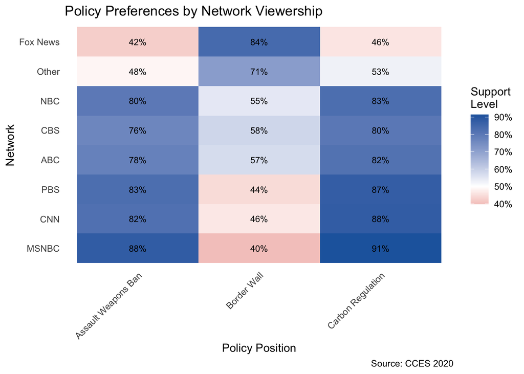

```r
# Reshape data for heatmap
network_policy_long <- network_policy_summary |>
  select(-n) |>
  pivot_longer(
    cols = ends_with("_support"),
    names_to = "policy",
    values_to = "support"
  ) |>
  mutate(
    # Clean up policy names for display
    policy = case_when(
      policy == "carbon_support" ~ "Carbon Regulation",
      policy == "border_support" ~ "Border Wall",
      policy == "assault_ban_support" ~ "Assault Weapons Ban"
    ),
    network = fct_relevel(network,
      "MSNBC", "CNN", "PBS", "ABC", "CBS", "NBC", "Other", "Fox News")
  )

# Create heatmap
ggplot(network_policy_long,
       aes(x = policy, y = network, fill = support)) +
  geom_tile() +
  scale_fill_gradient2(
    low = "#b2182b",    # Republican red
    mid = "white",
    high = "#2166ac",   # Democratic blue
    midpoint = 0.5,
    labels = scales::percent
  ) +
  # Add text labels
  geom_text(aes(label = scales::percent(support, accuracy = 1)),
            color = "black", size = 3) +
  labs(
    title = "Policy Preferences by Network Viewership",
    x = "Policy Position",
    y = "Network",
    fill = "Support\nLevel",
    caption = "Source: CCES 2020"
  ) +
  theme_minimal() +
  theme(
    axis.text.x = element_text(angle = 45, hjust = 1),
    panel.grid.major = element_blank(),
    panel.grid.minor = element_blank()
  )
```

```r
# Create dummy variables for watching each network
cc_media_policy <- cc_media_policy |>
  mutate(
    watches_fox = `300b_5` == 1,
    watches_msnbc = `300b_6` == 1,
    watches_cnn = `300b_4` == 1
  )

# Regression of ideology on network choice
mod_ideology <- lm(ideo5 ~ watches_fox + watches_msnbc + watches_cnn,
                  data = cc_media_policy)
summary(mod_ideology)
```

```
##
## Call:
## lm(formula = ideo5 ~ watches_fox + watches_msnbc + watches_cnn,
##     data = cc_media_policy)
##
## Residuals:
##     Min      1Q  Median      3Q     Max
## -2.9630 -0.9460  0.0370  0.5881  3.9836
##
## Coefficients:
##                   Estimate Std. Error t value Pr(>|t|)
## (Intercept)        2.94600    0.01191  247.37   <2e-16 ***
## watches_foxTRUE    1.01705    0.01441   70.57   <2e-16 ***
## watches_msnbcTRUE -0.53412    0.01609  -33.19   <2e-16 ***
## watches_cnnTRUE   -0.39551    0.01480  -26.72   <2e-16 ***
## ---
## Signif. codes:  0 '***' 0.001 '**' 0.01 '*' 0.05 '.' 0.1 ' ' 1
##
## Residual standard error: 1.099 on 25793 degrees of freedom
##   (35203 observations deleted due to missingness)
## Multiple R-squared:  0.2795, Adjusted R-squared:  0.2794
## F-statistic:  3336 on 3 and 25793 DF,  p-value: < 2.2e-16
```

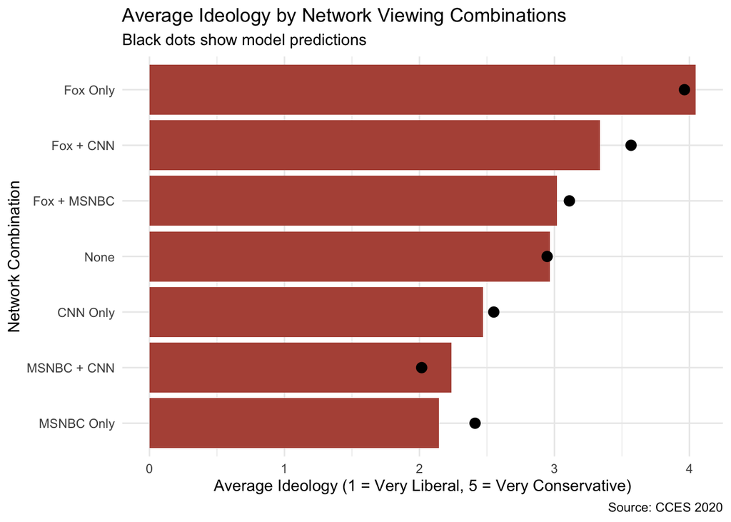

```r
# Create visualization with proper handling of missing values
cc_media_policy |>
  # First filter to only the complete cases used in the regression
  filter(!is.na(ideo5), !is.na(watches_fox), !is.na(watches_msnbc), !is.na(watches_cnn)) |>
  mutate(
    predicted_ideology = predict(mod_ideology),
    network_combo = case_when(
      watches_fox & !watches_msnbc & !watches_cnn ~ "Fox Only",
      !watches_fox & watches_msnbc & !watches_cnn ~ "MSNBC Only",
      !watches_fox & !watches_msnbc & watches_cnn ~ "CNN Only",
      watches_fox & watches_msnbc ~ "Fox + MSNBC",
      watches_fox & watches_cnn ~ "Fox + CNN",
      watches_msnbc & watches_cnn ~ "MSNBC + CNN",
      watches_fox & watches_msnbc & watches_cnn ~ "All Three",
      TRUE ~ "None"
    )
  ) |>
  group_by(network_combo) |>
  summarise(
    avg_ideology = mean(ideo5, na.rm = TRUE),
    pred_ideology = mean(predicted_ideology, na.rm = TRUE),
    n = n()
  ) |>
  filter(n > 100) |>  # Filter for combinations with sufficient data
  ggplot(aes(x = reorder(network_combo, avg_ideology), y = avg_ideology)) +
  geom_col(fill = "#b45346") +
  geom_point(aes(y = pred_ideology), color = "black", size = 3) +
  coord_flip() +
  labs(
    title = "Average Ideology by Network Viewing Combinations",
    subtitle = "Black dots show model predictions",
    x = "Network Combination",
    y = "Average Ideology (1 = Very Liberal, 5 = Very Conservative)",
    caption = "Source: CCES 2020"
  ) +
  theme_minimal()
```

# Conclusion

This analysis of CCES data reveals several important patterns in American TV news consumption. The findings demonstrate significant relationships between viewers’ ideological preferences, age, and network choices.

Limitations of this analysis include: - Reliance on self-reported viewing habits - Online-only survey methodology may underrepresent certain populations - Focus on traditional TV news excludes emerging digital media sources - Cross-sectional nature of the analysis limits causal inference

Future research could: - Examine how streaming and social media affect news consumption patterns - Track individual-level changes in viewing habits over time - Investigate the relationship between local news viewership and political attitudes - Compare U.S. patterns with those in other countries